# Indel Signature InsDel_A_alpha

# InsDel_Aα

**Note**

Compared to InsDel_A_alpha as extracted from the 476-type classification, InsDel_A_beta has mutations from GCT -> CT, as well as mutations at Del2:U1:R1, Del2:U(2,):R1 and Del2:M1.

(corresponds to 83-type signature ID_A)

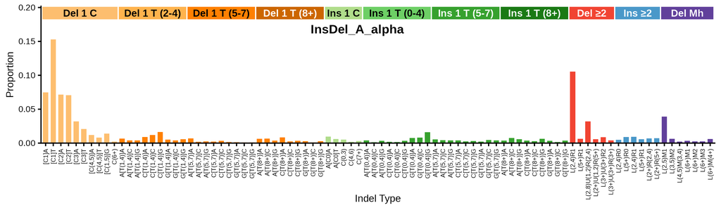

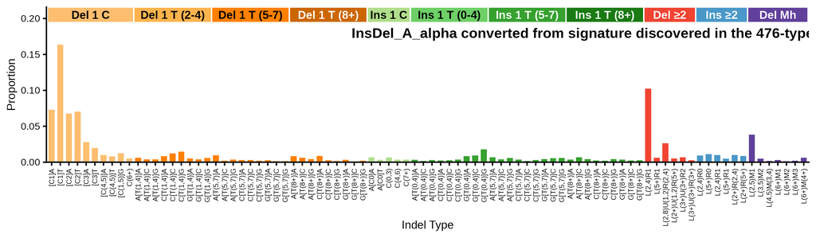

89-type spectrum of the linking tumor CPCT02120078T | cosine similarity to InsDel_A_alpha: 0.8097

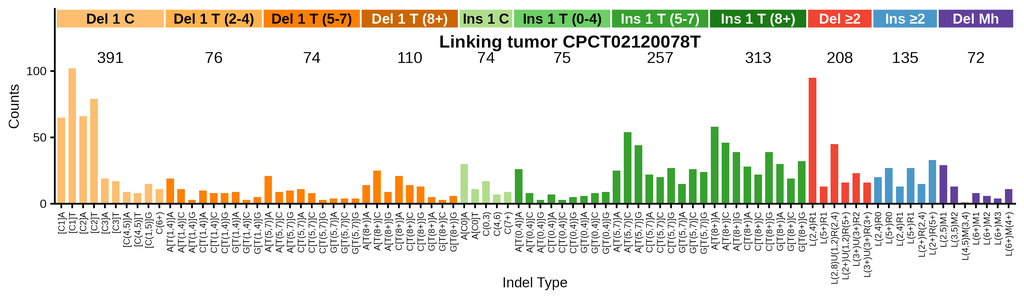

**Click to view decomposition of the linking tumor spectrum**

Partial mutation signature of CPCT02120078T due to InsDel_A_alpha

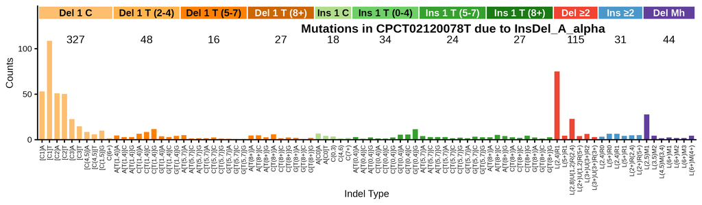

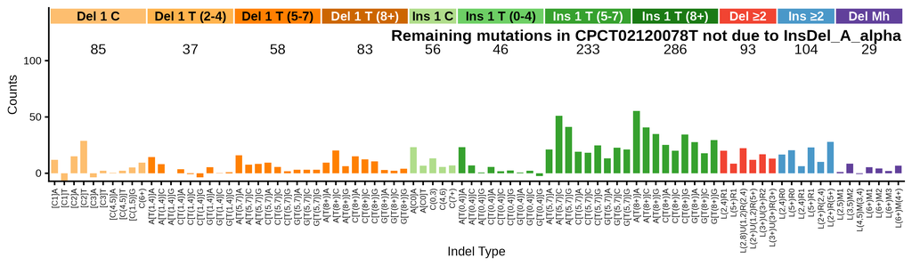

Max neg fraction (maximum allowed negative residual count as fraction of total): 0.01  
N subtract (mutation count assigned to signature): 711.2  
N residual (mutation count in residual “partial spectrum”): 1073.8  
Total negative (sum of negative residual mutation counts): 17.8  
N negative channels (number of channels with negative residual): 6  
P(≥ total negative) (Monte Carlo estimated probability that negative-binomial-sampled spectra from the signature contributing N subtract mutations would produce a total negative count >= the observed Total negative; higher number means not surprising): 0.916

**Per-channel residual breakdown**

| Channel | Spectrum | Sig_Count | Residual | Sig_Prop |
| --- | --- | --- | --- | --- |
| [Del(C):R1]A | 65 | 53.1 | 11.9 | 0.07473 |
| [Del(C):R1]T | 102 | 108.8 | -6.8 | 0.15293 |
| [Del(C):R2]A | 66 | 50.9 | 15.1 | 0.07162 |
| [Del(C):R2]T | 79 | 50.3 | 28.7 | 0.07075 |
| [Del(C):R3]A | 19 | 22.7 | -3.7 | 0.03188 |
| [Del(C):R3]T | 17 | 14.8 | 2.2 | 0.02077 |
| [Del(C):R(4,5)]A | 9 | 8.6 | 0.4 | 0.01204 |
| [Del(C):R(4,5)]T | 8 | 5.8 | 2.2 | 0.00822 |
| [Del(C):R(1,5)]G | 15 | 9.9 | 5.1 | 0.01397 |
| Del(C):R(6,9) | 11 | 1.6 | 9.4 | 0.00223 |
| A[Del(T):R(1,4)]A | 19 | 4.7 | 14.3 | 0.00662 |
| A[Del(T):R(1,4)]C | 11 | 2.9 | 8.1 | 0.00407 |
| A[Del(T):R(1,4)]G | 3 | 2.9 | 0.1 | 0.00409 |
| C[Del(T):R(1,4)]A | 10 | 6.5 | 3.5 | 0.00914 |
| C[Del(T):R(1,4)]C | 8 | 8.6 | -0.6 | 0.01207 |
| C[Del(T):R(1,4)]G | 8 | 11.7 | -3.7 | 0.01644 |
| G[Del(T):R(1,4)]A | 9 | 3.7 | 5.3 | 0.00524 |
| G[Del(T):R(1,4)]C | 3 | 2.8 | 0.2 | 0.00399 |
| G[Del(T):R(1,4)]G | 5 | 4.1 | 0.9 | 0.00574 |
| A[Del(T):R(5,7)]A | 21 | 5.0 | 16 | 0.00699 |
| A[Del(T):R(5,7)]C | 9 | 1.4 | 7.6 | 0.00199 |
| A[Del(T):R(5,7)]G | 10 | 1.7 | 8.3 | 0.00239 |
| C[Del(T):R(5,7)]A | 11 | 1.7 | 9.3 | 0.00236 |
| C[Del(T):R(5,7)]C | 8 | 2.4 | 5.6 | 0.00343 |
| C[Del(T):R(5,7)]G | 3 | 1.2 | 1.8 | 0.00164 |
| G[Del(T):R(5,7)]A | 4 | 0.9 | 3.1 | 0.00133 |
| G[Del(T):R(5,7)]C | 4 | 0.8 | 3.2 | 0.00108 |
| G[Del(T):R(5,7)]G | 4 | 0.8 | 3.2 | 0.00112 |
| A[Del(T):R(8,)]A | 14 | 4.6 | 9.4 | 0.00644 |
| A[Del(T):R(8,)]C | 25 | 4.8 | 20.2 | 0.00673 |

[output cut: 59 more lines]

## 476-type representations corresponding to InsDel_A_alpha

Extracted 476-type signature corresponding to InsDel_A_alpha

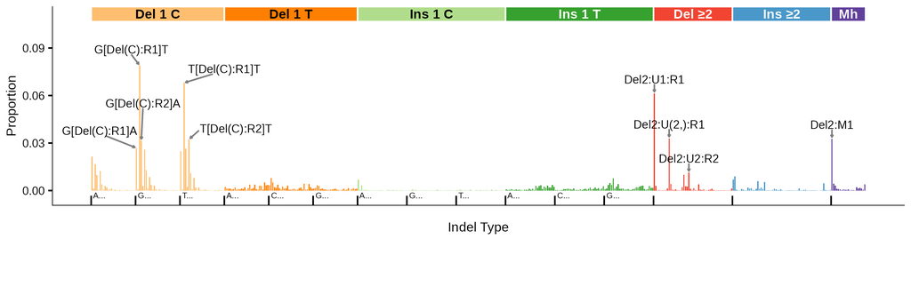

476-type spectrum of the linking tumor CPCT02120078T; cosine similarity to the extracted 476-type signature is 0.7636

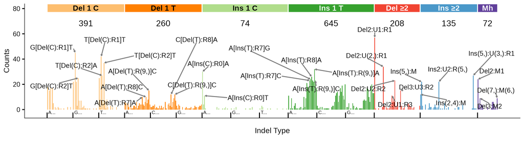

## 83-type signature corresponding to InsDel_A_alpha (ID_A)

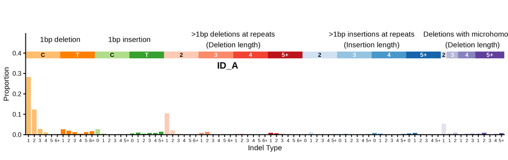

83-type signature converted from signature discovered in the 476-type spectra (using bipartite matching optimization) | cosine similarity to ID_A: 0.9597

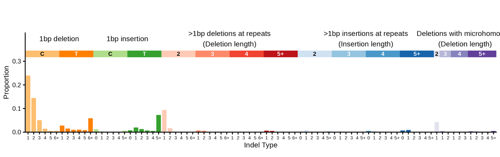

**Click to see flow diagrams: 476-type to 83-type collapse**

These Sankey diagrams show how the 476-type mutation categories are redistributed to 83-type categories using bipartite matching. We only show the diagrams for insertions or deletions of > 1 base because it is for these indels that 476-type categories map to > 1 83-type category.

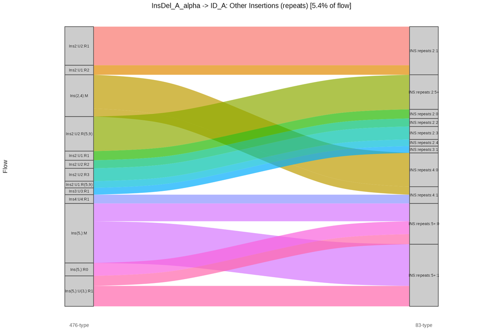

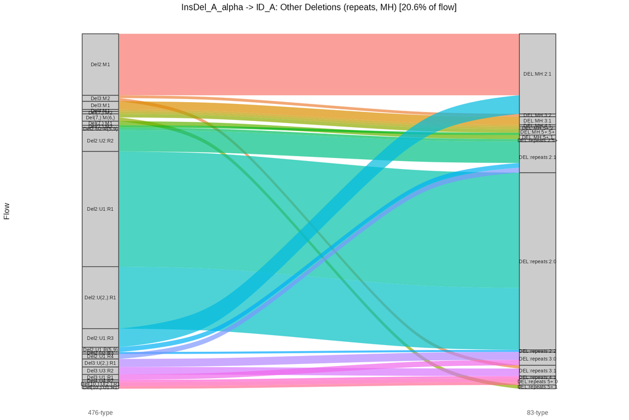

83-type spectrum of the linking tumor CPCT02120078T | cosine similarity to ID_A: 0.4338

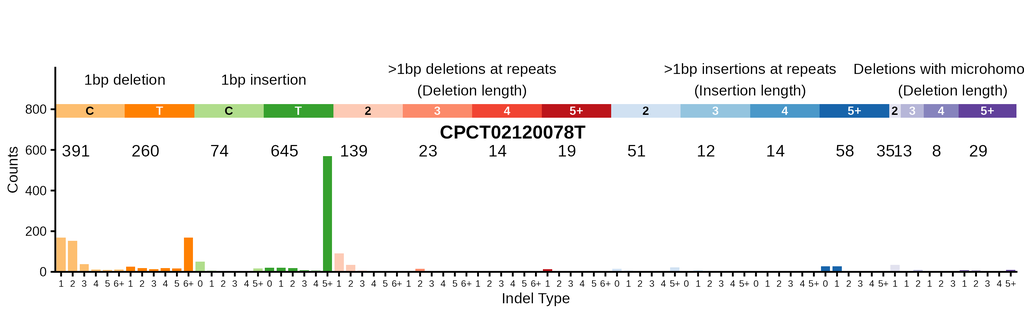

**Click here to see with insertions and deletions of T in long poly-T suppressed**

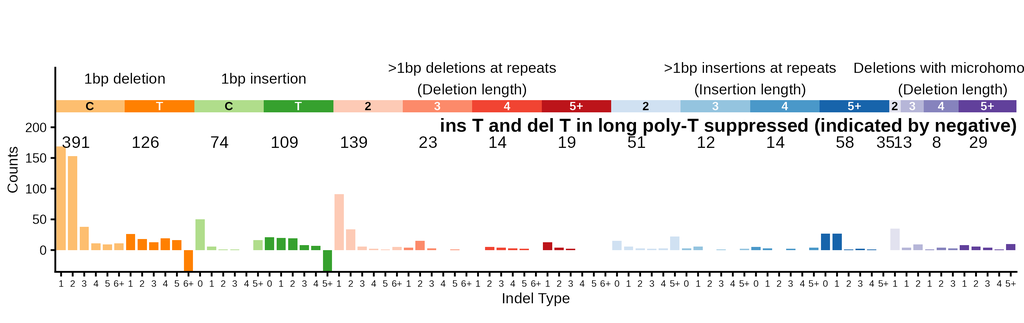

83-type spectrum of best 83-type matching tumor SP2293 | cosine similarity to ID_A: 0.8227

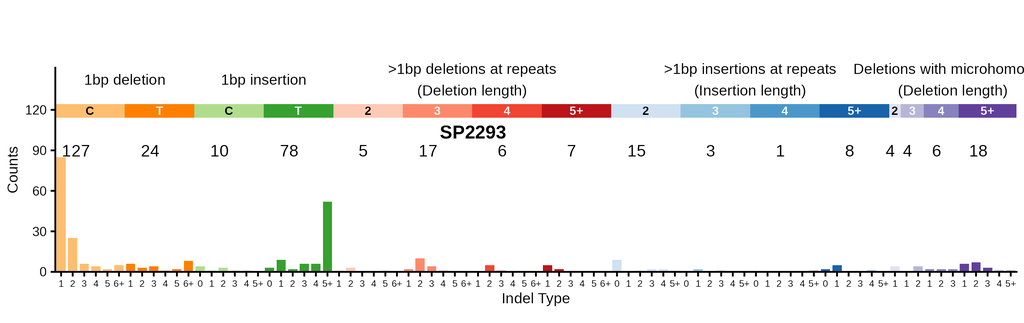

**Click here to see with insertions and deletions of T in long poly-T suppressed**

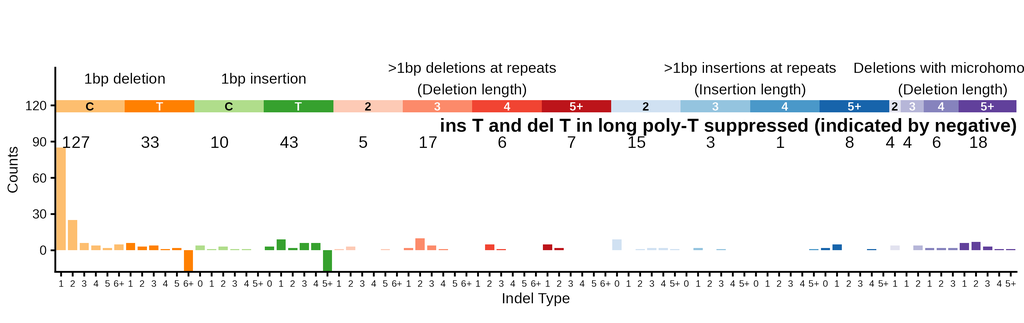